# solar demostration

### this ".ipynb" file produces the graphical and numerical results for solar demonstration </font>

### this demostration is not included in the paper </font>

### we set it up for the step-by-step illustration of solar computation </font>

## Check the following before running the code

### (a) To avoid confusion, reset your kernel before you running the notebook (to clear memory): Menu "Kernel" $\rightarrow$ "Restart Kernel and clear all outputs".

### (b) To evaluate the code for simulation replication,

- click : Menu "Kernel" $\rightarrow$ "Restart Kernel and Run All Cells"
- or, select a cell of code, press "shift" and "enter". Run all cells to avoid errors

### (c) Check "joblib", "scikit-learn", "numpy", "matplotlib" and "tqdm" are installed. If not,

- run "pip install joblib scikit-learn numpy matplotlib tqdm" in terminal (Mac OS or Linux) or command prompt as administrator (Windows) if you use Python3 without any IDE.
- we highly recommend installing Anaconda3 directly to avoid unecessary package management (all packages mentioned above are installed by default).

## #1: import all modules

- For simplicity and elegancy, all relevant functions and classes are coded in "solar_simul_demo.py".

```python
import numpy             as np
import matplotlib.pyplot as plt

from solar_simul_demo import one_shot_simul
```

## #2(a): define inputs values

| variable name | meaning |
| --- | --- |
| sample_size | the sample size $n$ in the paper; |
| n_dim | the number of variables(informative + redundant) in $X$, $p$ in the paper; |
| n_info | the number of informative variables in $X$; |
| n_repeat | the number of subsamples generated by solar; |
| step_size | the step size for tuning $c$; |
| rnd_seed | the random seed value; |
| plot_on | the binary value that controls whether the simulation plots will be saved as PDF; |

### #2(b): define DGP

- the population regression equation is $$Y = 2\cdot \mathbf{x}_0 + 3\cdot \mathbf{x}_1 + 4\cdot \mathbf{x}_2 + 5\cdot \mathbf{x}_3 + 6\cdot \mathbf{x}_4 + y,$$
- To change the simulation settings, simply change the input values. If you change *n_info* you will adjust the DGP as follows:
  - If $i > \mbox{n_info} - 1$ and $i \in \left[ 0, 1, 2, \ldots, p-1 \right]$, $\beta_i = 0$ in population;
  - If $i \leqslant \mbox{n_info} - 1$ and $i \in \left[ 0, 1, 2, \ldots, p-1 \right]$, $\beta_i = i + 2$ in population

```python
sample_size = 200
n_dim       = 100
n_info      = 5
n_repeat    = 10
step_size   = -0.02
rnd_seed    = 0
plot_on     = False
```

## #4: compute solar, CV-lars-lasso (lasso solved by CV-lars) and CV-cd (lasso solved by warm-start cylindrical coordinate descent)

### Numpy, sklearn and python are actively updated. If you use different version, replication results may be slightly different from the paper (see Read_me_first.docx for detail).

```python
#control the random seed for reproduction
np.random.seed(rnd_seed)
```

### first, we call the class for simulation from "solar_simul_demo.py"

```python
trial = one_shot_simul(sample_size, n_dim, n_info, n_repeat,  step_size, rnd_seed, plot_on)
```

### then we compute cv-lars-lasso, cv-cd and solar on the simulated data and return the result

```python
solar_coef, opt_c, test_error, Qc_list, la_list, la_vari_list, cd_list, cd_vari_list = trial.simul_func()
```

## #4: plots and results of the simulation

### first, we plot the result of $c$ tuning (via validation error minimization) in algorithm 2

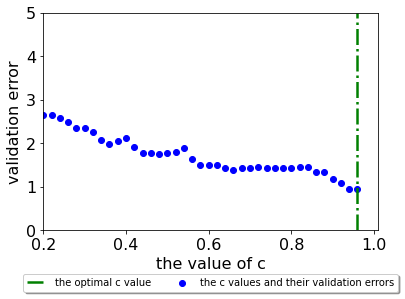

```python
trial.q_plot(test_error, opt_c)
```

### then we report the $Q(c) = \left\{ \mathbf{x}_j \; \vert \; \widehat{q}_j \geqslant c \right\}$ under different value of $c$.

```python
trial.q_list(Qc_list)
```

```
q_hat value >=  1.0
[['X4']]
q_hat value >=  0.9777777777777777
[['X4'], ['X3', 'X2']]
q_hat value >=  0.9555555555555556
[['X4'], ['X3', 'X2'], ['X1', 'X0']]
q_hat value >=  0.9111111111111111
[['X4'], ['X3', 'X2'], ['X1', 'X0'], ['X19', 'X18']]
q_hat value >=  0.8888888888888888
[['X4'], ['X3', 'X2'], ['X1', 'X0'], ['X19', 'X18'], ['X68']]
q_hat value >=  0.8666666666666667
[['X4'], ['X3', 'X2'], ['X1', 'X0'], ['X19', 'X18'], ['X68'], ['X71', 'X40']]
q_hat value >=  0.8222222222222222
[['X4'], ['X3', 'X2'], ['X1', 'X0'], ['X19', 'X18'], ['X68'], ['X71', 'X40'], ['X37']]
q_hat value >=  0.7777777777777778
[['X4'], ['X3', 'X2'], ['X1', 'X0'], ['X19', 'X18'], ['X68'], ['X71', 'X40'], ['X37'], ['X91']]
q_hat value >=  0.7111111111111111
[['X4'], ['X3', 'X2'], ['X1', 'X0'], ['X19', 'X18'], ['X68'], ['X71', 'X40'], ['X37'], ['X91'], ['X72', 'X35']]
q_hat value >=  0.6888888888888889
[['X4'], ['X3', 'X2'], ['X1', 'X0'], ['X19', 'X18'], ['X68'], ['X71', 'X40'], ['X37'], ['X91'], ['X72', 'X35'], ['X15']]
q_hat value >=  0.6666666666666666
[['X4'], ['X3', 'X2'], ['X1', 'X0'], ['X19', 'X18'], ['X68'], ['X71', 'X40'], ['X37'], ['X91'], ['X72', 'X35'], ['X15'], ['X59']]
q_hat value >=  0.6444444444444445
[['X4'], ['X3', 'X2'], ['X1', 'X0'], ['X19', 'X18'], ['X68'], ['X71', 'X40'], ['X37'], ['X91'], ['X72', 'X35'], ['X15'], ['X59'], ['X94']]
q_hat value >=  0.6222222222222222
[['X4'], ['X3', 'X2'], ['X1', 'X0'], ['X19', 'X18'], ['X68'], ['X71', 'X40'], ['X37'], ['X91'], ['X72', 'X35'], ['X15'], ['X59'], ['X94'], ['X28']]
q_hat value >=  0.6
[['X4'], ['X3', 'X2'], ['X1', 'X0'], ['X19', 'X18'], ['X68'], ['X71', 'X40'], ['X37'], ['X91'], ['X72', 'X35'], ['X15'], ['X59'], ['X94'], ['X28'], ['X70', 'X58', 'X17']]
q_hat value >=  0.5777777777777777
[['X4'], ['X3', 'X2'], ['X1', 'X0'], ['X19', 'X18'], ['X68'], ['X71', 'X40'], ['X37'], ['X91'], ['X72', 'X35'], ['X15'], ['X59'], ['X94'], ['X28'], ['X70', 'X58', 'X17'], ['X88']]
q_hat value >=  0.5555555555555556
[['X4'], ['X3', 'X2'], ['X1', 'X0'], ['X19', 'X18'], ['X68'], ['X71', 'X40'], ['X37'], ['X91'], ['X72', 'X35'], ['X15'], ['X59'], ['X94'], ['X28'], ['X70', 'X58', 'X17'], ['X88'], ['X41']]
q_hat value >=  0.5111111111111111
[['X4'], ['X3', 'X2'], ['X1', 'X0'], ['X19', 'X18'], ['X68'], ['X71', 'X40'], ['X37'], ['X91'], ['X72', 'X35'], ['X15'], ['X59'], ['X94'], ['X28'], ['X70', 'X58', 'X17'], ['X88'], ['X41'], ['X64', 'X62', 'X51', 'X31', 'X26']]
q_hat value >=  0.4888888888888889
[['X4'], ['X3', 'X2'], ['X1', 'X0'], ['X19', 'X18'], ['X68'], ['X71', 'X40'], ['X37'], ['X91'], ['X72', 'X35'], ['X15'], ['X59'], ['X94'], ['X28'], ['X70', 'X58', 'X17'], ['X88'], ['X41'], ['X64', 'X62', 'X51', 'X31', 'X26'], ['X45', 'X24', 'X20']]
q_hat value >=  0.4666666666666667
[['X4'], ['X3', 'X2'], ['X1', 'X0'], ['X19', 'X18'], ['X68'], ['X71', 'X40'], ['X37'], ['X91'], ['X72', 'X35'], ['X15'], ['X59'], ['X94'], ['X28'], ['X70', 'X58', 'X17'], ['X88'], ['X41'], ['X64', 'X62', 'X51', 'X31', 'X26'], ['X45', 'X24', 'X20'], ['X93', 'X90', 'X74', 'X67', 'X56', 'X52', 'X34', '…
q_hat value >=  0.4444444444444444
[['X4'], ['X3', 'X2'], ['X1', 'X0'], ['X19', 'X18'], ['X68'], ['X71', 'X40'], ['X37'], ['X91'], ['X72', 'X35'], ['X15'], ['X59'], ['X94'], ['X28'], ['X70', 'X58', 'X17'], ['X88'], ['X41'], ['X64', 'X62', 'X51', 'X31', 'X26'], ['X45', 'X24', 'X20'], ['X93', 'X90', 'X74', 'X67', 'X56', 'X52', 'X34', '…
```

[output cut: 17 more lines]

```
[['X4'], ['X3', 'X2'], ['X1', 'X0'], ['X19', 'X18'], ['X68'], ['X71', 'X40'], ['X37'], ['X91'], ['X72', 'X35'], ['X15'], ['X59'], ['X94'], ['X28'], ['X70', 'X58', 'X17'], ['X88'], ['X41'], ['X64', 'X62', 'X51', 'X31', 'X26'], ['X45', 'X24', 'X20'], ['X93', 'X90', 'X74', 'X67', 'X56', 'X52', 'X34', '…
q_hat value >=  0.2222222222222222
[['X4'], ['X3', 'X2'], ['X1', 'X0'], ['X19', 'X18'], ['X68'], ['X71', 'X40'], ['X37'], ['X91'], ['X72', 'X35'], ['X15'], ['X59'], ['X94'], ['X28'], ['X70', 'X58', 'X17'], ['X88'], ['X41'], ['X64', 'X62', 'X51', 'X31', 'X26'], ['X45', 'X24', 'X20'], ['X93', 'X90', 'X74', 'X67', 'X56', 'X52', 'X34', '…
q_hat value >=  0.2
[['X4'], ['X3', 'X2'], ['X1', 'X0'], ['X19', 'X18'], ['X68'], ['X71', 'X40'], ['X37'], ['X91'], ['X72', 'X35'], ['X15'], ['X59'], ['X94'], ['X28'], ['X70', 'X58', 'X17'], ['X88'], ['X41'], ['X64', 'X62', 'X51', 'X31', 'X26'], ['X45', 'X24', 'X20'], ['X93', 'X90', 'X74', 'X67', 'X56', 'X52', 'X34', '…
q_hat value >=  0.17777777777777778
[['X4'], ['X3', 'X2'], ['X1', 'X0'], ['X19', 'X18'], ['X68'], ['X71', 'X40'], ['X37'], ['X91'], ['X72', 'X35'], ['X15'], ['X59'], ['X94'], ['X28'], ['X70', 'X58', 'X17'], ['X88'], ['X41'], ['X64', 'X62', 'X51', 'X31', 'X26'], ['X45', 'X24', 'X20'], ['X93', 'X90', 'X74', 'X67', 'X56', 'X52', 'X34', '…
q_hat value >=  0.15555555555555556
[['X4'], ['X3', 'X2'], ['X1', 'X0'], ['X19', 'X18'], ['X68'], ['X71', 'X40'], ['X37'], ['X91'], ['X72', 'X35'], ['X15'], ['X59'], ['X94'], ['X28'], ['X70', 'X58', 'X17'], ['X88'], ['X41'], ['X64', 'X62', 'X51', 'X31', 'X26'], ['X45', 'X24', 'X20'], ['X93', 'X90', 'X74', 'X67', 'X56', 'X52', 'X34', '…
q_hat value >=  0.13333333333333333
[['X4'], ['X3', 'X2'], ['X1', 'X0'], ['X19', 'X18'], ['X68'], ['X71', 'X40'], ['X37'], ['X91'], ['X72', 'X35'], ['X15'], ['X59'], ['X94'], ['X28'], ['X70', 'X58', 'X17'], ['X88'], ['X41'], ['X64', 'X62', 'X51', 'X31', 'X26'], ['X45', 'X24', 'X20'], ['X93', 'X90', 'X74', 'X67', 'X56', 'X52', 'X34', '…
q_hat value >=  0.06666666666666667
[['X4'], ['X3', 'X2'], ['X1', 'X0'], ['X19', 'X18'], ['X68'], ['X71', 'X40'], ['X37'], ['X91'], ['X72', 'X35'], ['X15'], ['X59'], ['X94'], ['X28'], ['X70', 'X58', 'X17'], ['X88'], ['X41'], ['X64', 'X62', 'X51', 'X31', 'X26'], ['X45', 'X24', 'X20'], ['X93', 'X90', 'X74', 'X67', 'X56', 'X52', 'X34', '…
q_hat value >=  0.044444444444444446
[['X4'], ['X3', 'X2'], ['X1', 'X0'], ['X19', 'X18'], ['X68'], ['X71', 'X40'], ['X37'], ['X91'], ['X72', 'X35'], ['X15'], ['X59'], ['X94'], ['X28'], ['X70', 'X58', 'X17'], ['X88'], ['X41'], ['X64', 'X62', 'X51', 'X31', 'X26'], ['X45', 'X24', 'X20'], ['X93', 'X90', 'X74', 'X67', 'X56', 'X52', 'X34', '…
```

### then we report solar regression coefficents

```python
print(solar_coef)
```

```
[[1.90590232]
 [2.92660102]
 [3.94706396]
 [5.06522281]
 [6.12764936]
 [0.        ]
 [0.        ]
 [0.        ]
 [0.        ]
 [0.        ]
 [0.        ]
 [0.        ]
 [0.        ]
 [0.        ]
 [0.        ]
 [0.        ]
 [0.        ]
 [0.        ]
 [0.        ]
 [0.        ]
 [0.        ]
 [0.        ]
 [0.        ]
 [0.        ]
 [0.        ]
 [0.        ]
 [0.        ]
 [0.        ]
 [0.        ]
 [0.        ]
 [0.        ]
 [0.        ]
 [0.        ]
 [0.        ]
 [0.        ]
 [0.        ]
 [0.        ]
 [0.        ]
 [0.        ]
 [0.        ]
```

[output cut: 45 more lines]

```
 [0.        ]
 [0.        ]
 [0.        ]
 [0.        ]
 [0.        ]
 [0.        ]
 [0.        ]
 [0.        ]
 [0.        ]
 [0.        ]
 [0.        ]
 [0.        ]
 [0.        ]
 [0.        ]
 [0.        ]]
```

### the reason we print max(opt_c) is because sometimes multiple values of $c$ is assigned with the same value of validation error

```python
print(max(opt_c))
```

```
0.96
```

### and the number of variables selected by cv-lars-lasso

```python
print(la_list)
```

```
14
```

### and the number of variables selected by cv-cd

```python
print(cd_list)
```

```
17
```

### and variables selected by cv-lars-lasso

```python
print('variables selected by cv-lars-lasso: ', [ 'X' + str(i) for i in la_vari_list])
```

```
variables selected by cv-lars-lasso:  ['X4', 'X3', 'X2', 'X1', 'X0', 'X71', 'X91', 'X90', 'X17', 'X40', 'X70', 'X65', 'X94', 'X28']
```

### and variables selected by cv-cd

```python
print('variables selected by cv-cd: ', [ 'X' + str(i) for i in cd_vari_list])
```

```
variables selected by cv-cd:  ['X0', 'X1', 'X2', 'X3', 'X4', 'X17', 'X19', 'X28', 'X31', 'X40', 'X41', 'X65', 'X70', 'X71', 'X90', 'X91', 'X94']
```

### Finally we produce the HTML file

```python
!rm -rf solar_demo.html
!jupyter nbconvert --to html solar_demo.ipynb
```

```
[NbConvertApp] Converting notebook solar_demo.ipynb to html
[NbConvertApp] Writing 638656 bytes to solar_demo.html
```